Saltar al contenido principal

# DISTRIBUCIONES DE FRECUENCIAS

TALLER DE ESTADÍSTICA DESCRIPTIVA - ANÁLISIS DEL SECTOR PÚBLICO

Autor/a

Afiliación

Jose David Rodriguez Cortes

[Escuela Superior de Administración Pública (ESAP)](https://www.esap.edu.co/)

Fecha de publicación

16 de noviembre de 2026

**Ver código**

```r
options(
  knitr.table.format = "html",
  scipen = 999
)
```

[figure not shown]

# 1 .Cargar paquetes

**Ver código**

```r
ipak <- function(pkg){

  options(repos = c(CRAN="https://cloud.r-project.org"))

  new.pkg <- pkg[!(pkg %in% rownames(installed.packages()))]

  if(length(new.pkg)) install.packages(new.pkg, dependencies = TRUE)

  invisible(lapply(pkg, function(p)
    suppressPackageStartupMessages(library(p, character.only = TRUE))
  ))
}

packages <- c("tidyverse","kableExtra","psych","readxl")

ipak(packages)
```

# 2 Introducción y Diccionario de Variables

El presente informe desarrolla el análisis estadístico descriptivo univariado para una muestra representativa de $n = 200$ servidores públicos pertenecientes a distintas dependencias del Estado, registrados en la base de datos `sector.xlsx`. El propósito principal consiste en caracterizar las condiciones socioeconómicas, demográficas y de percepción del talento humano a través de tablas completas de distribución de frecuencias, estadísticos de resumen y representaciones gráficas especializadas.

A continuación se resume la estructura y clasificación metodológica de las 10 variables analizadas, según lo estipulado en el *Diccionario de Variables*:

**Ver código**

```r
diccionario <- tibble::tribble(
  ~`N°`, ~Variable, ~Tipo, ~Escala, ~Descripción, ~Valores_Rango,
  "1", "Sector_Laboral", "Cualitativa", "Nominal", "Sector de la administración pública donde labora el encuestado", "Seguridad, Educación, Salud, Transporte, Administrativo",
  "2", "Nivel_Ingresos", "Cualitativa", "Ordinal", "Nivel salarial o de ingresos socioeconómicos percibido", "Baja < Media < Alta",
  "3", "Satisfaccion_Servicio", "Cualitativa", "Ordinal", "Nivel de satisfacción con los servicios recibidos o brindados", "Muy Insatisfecho < Insatisfecho < Neutral < Satisfecho < Muy Satisfecho",
  "4", "Frecuencia_Participacion", "Cualitativa", "Ordinal", "Frecuencia de participación en programas de la administración", "Nunca < Rara vez < A veces < Frecuentemente < Siempre",
  "5", "Anos_Experiencia", "Cuantitativa", "Discreta", "Años enteros de experiencia laboral en el sector público", "Números enteros de 0 a 20 años",
  "6", "Numero_Hijos", "Cuantitativa", "Discreta", "Número total de hijos a cargo del servidor público", "Números enteros de 1 a 5 hijos",
  "7", "Salario", "Cuantitativa", "Continua", "Salario mensual del funcionario (en miles de pesos COP)", "Valores continuos de 1000 a 5000 miles COP",
  "8", "Satisfaccion_Laboral", "Cuantitativa", "Continua", "Puntuación continua de satisfacción con el clima laboral", "Escala continua de 0.5 a 2.5 puntos",
  "9", "Edad", "Cuantitativa", "Continua", "Edad biológica del funcionario en años cumplidos", "Rango continuo de 20 a 60 años",
  "10", "Participacion_Programas", "Cuantitativa", "Continua", "Proporción de participación en programas de capacitación", "Rango continuo de 0.1 a 1.0 (10% a 100%)"
)

kbl(diccionario, caption = "Diccionario de Variables: Clasificación Estadística y Metodológica (sector.xlsx)") |>
  kable_styling(bootstrap_options = c("striped", "hover", "condensed", "responsive"), full_width = TRUE) |>
  row_spec(0, bold = TRUE, background = "#2b5c8f", color = "white")
```

Diccionario de Variables: Clasificación Estadística y Metodológica (sector.xlsx)

| N° | Variable | Tipo | Escala | Descripción | Valores_Rango |
| --- | --- | --- | --- | --- | --- |
| 1 | Sector_Laboral | Cualitativa | Nominal | Sector de la administración pública donde labora el encuestado | Seguridad, Educación, Salud, Transporte, Administrativo |
| 2 | Nivel_Ingresos | Cualitativa | Ordinal | Nivel salarial o de ingresos socioeconómicos percibido | Baja < Media < Alta |
| 3 | Satisfaccion_Servicio | Cualitativa | Ordinal | Nivel de satisfacción con los servicios recibidos o brindados | Muy Insatisfecho < Insatisfecho < Neutral < Satisfecho < Muy Satisfecho |
| 4 | Frecuencia_Participacion | Cualitativa | Ordinal | Frecuencia de participación en programas de la administración | Nunca < Rara vez < A veces < Frecuentemente < Siempre |
| 5 | Anos_Experiencia | Cuantitativa | Discreta | Años enteros de experiencia laboral en el sector público | Números enteros de 0 a 20 años |
| 6 | Numero_Hijos | Cuantitativa | Discreta | Número total de hijos a cargo del servidor público | Números enteros de 1 a 5 hijos |
| 7 | Salario | Cuantitativa | Continua | Salario mensual del funcionario (en miles de pesos COP) | Valores continuos de 1000 a 5000 miles COP |
| 8 | Satisfaccion_Laboral | Cuantitativa | Continua | Puntuación continua de satisfacción con el clima laboral | Escala continua de 0.5 a 2.5 puntos |
| 9 | Edad | Cuantitativa | Continua | Edad biológica del funcionario en años cumplidos | Rango continuo de 20 a 60 años |
| 10 | Participacion_Programas | Cuantitativa | Continua | Proporción de participación en programas de capacitación | Rango continuo de 0.1 a 1.0 (10% a 100%) |

# 3 Importación y Preparación de la Base de Datos

Se procede con la lectura del archivo `sector.xlsx` correspondiente a la hoja `Sheet1`, la transformación rigurosa de las tres variables ordinales en factores con niveles ordenados (`ordered = TRUE`) y la verificación de integridad de datos.

**Ver código**

```r
# 1. Lectura de la base de datos
datos <- read_excel("sector.xlsx", sheet = "Sheet1")

# 2. Transformación de variables ordinales respetando su jerarquía intrínseca
datos$Nivel_Ingresos <- factor(
  datos$Nivel_Ingresos,
  levels = c("Baja", "Media", "Alta"),
  ordered = TRUE
)

datos$Satisfaccion_Servicio <- factor(
  datos$Satisfaccion_Servicio,
  levels = c("Muy Insatisfecho", "Insatisfecho", "Neutral", "Satisfecho", "Muy Satisfecho"),
  ordered = TRUE
)

datos$Frecuencia_Participacion <- factor(
  datos$Frecuencia_Participacion,
  levels = c("Nunca", "Rara vez", "A veces", "Frecuentemente", "Siempre"),
  ordered = TRUE
)

# 3. Verificación de dimensiones y valores faltantes
dimensiones <- dim(datos)
faltantes <- sum(is.na(datos))

cat("Dimensiones de la base: ", dimensiones[1], " filas y ", dimensiones[2], " columnas.\n")
```

```
Dimensiones de la base:  200  filas y  10  columnas.
```

**Ver código**

```r
cat("Total de valores faltantes (NA): ", faltantes, ".\n")
```

```
Total de valores faltantes (NA):  0 .
```

**Ver código**

```r
# 4. Vista previa de los primeros 10 registros
head(datos, 10) |>
  kbl(caption = "Muestra inicial de 10 registros de la base de datos sector.xlsx") |>
  kable_styling(bootstrap_options = c("striped", "hover", "condensed", "responsive"), full_width = FALSE) |>
  row_spec(0, bold = TRUE, background = "#34495e", color = "white")
```

Muestra inicial de 10 registros de la base de datos sector.xlsx

| Sector_Laboral | Nivel_Ingresos | Satisfaccion_Servicio | Frecuencia_Participacion | Anos_Experiencia | Numero_Hijos | Salario | Satisfaccion_Laboral | Edad | Participacion_Programas |
| --- | --- | --- | --- | --- | --- | --- | --- | --- | --- |
| Educación | Baja | Satisfecho | Siempre | 17 | 5 | 4541 | 2.03 | 56 | 0.347 |
| Seguridad | Alta | Satisfecho | Siempre | 18 | 4 | 2077 | 1.95 | 27 | 0.125 |
| Transporte | Baja | Insatisfecho | Rara vez | 19 | 2 | 3376 | 0.74 | 31 | 0.484 |
| Seguridad | Alta | Satisfecho | Nunca | 20 | 4 | 4273 | 1.35 | 46 | 0.436 |
| Administrativo | Alta | Muy Satisfecho | A veces | 7 | 4 | 4520 | 2.14 | 36 | 0.142 |
| Seguridad | Baja | Insatisfecho | Rara vez | 18 | 3 | 4715 | 0.78 | 46 | 0.742 |
| Transporte | Alta | Muy Insatisfecho | A veces | 8 | 4 | 4660 | 2.45 | 49 | 0.437 |
| Educación | Alta | Insatisfecho | Frecuentemente | 8 | 2 | 2691 | 1.78 | 46 | 0.108 |
| Sector Salud | Media | Muy Insatisfecho | Rara vez | 18 | 5 | 2100 | 1.87 | 58 | 0.812 |
| Seguridad | Alta | Insatisfecho | Nunca | 6 | 1 | 1990 | 1.01 | 23 | 0.953 |

**Ver código**

```r
# ==============================================================================
# FUNCIONES AUXILIARES PARA DISTRIBUCIONES DE FRECUENCIAS Y ESTADÍSTICOS
# ==============================================================================

# Función para variables Categóricas (Nominales y Ordinales) y Discretas
generar_tabla_cat <- function(vector_datos, nombre_columna = "Categoría") {
  n_total <- length(vector_datos)
  tb <- as.data.frame(table(vector_datos))
  colnames(tb) <- c("x_i", "f_i")

  tb <- tb %>%
    mutate(
      F_i = cumsum(f_i),
      h_i = f_i / n_total,
      H_i = cumsum(h_i),
      p_i = h_i * 100,
      P_i = H_i * 100
    )

  tb_formateada <- tb %>%
    mutate(
      h_i_txt = sprintf("%.4f", h_i),
      H_i_txt = sprintf("%.4f", H_i),
      p_i_txt = sprintf("%.2f%%", p_i),
      P_i_txt = sprintf("%.2f%%", P_i)
    ) %>%
    select(x_i, f_i, F_i, h_i_txt, H_i_txt, p_i_txt, P_i_txt)

  fila_total <- data.frame(
    x_i = "Total",
    f_i = n_total,
    F_i = "-",
    h_i_txt = "1.0000",
    H_i_txt = "-",
    p_i_txt = "100.00%",
    P_i_txt = "-"
  )

  tabla_final <- rbind(tb_formateada, fila_total)
  colnames(tabla_final) <- c(
    paste0(nombre_columna, " (xᵢ)"),
    "fᵢ", "Fᵢ", "hᵢ", "Hᵢ", "pᵢ (%)", "Pᵢ (%)"
  )
  return(tabla_final)
}

# Función para variables Continuas agrupadas por la Regla de Sturges (k = 9)
generar_tabla_continua <- function(vector_datos, k = 9, digits = 2, nombre_columna = "Intervalo") {
  n_total <- length(vector_datos)
  min_val <- min(vector_datos)
  max_val <- max(vector_datos)

  breaks <- seq(min_val, max_val, length.out = k + 1)
  fmt <- paste0("%.", digits, "f")

  # Construcción de etiquetas explícitas [Li, Ls) y la última [Lk, L_{k+1}]
  labels_int <- character(k)
  for (i in 1:k) {
    c_close <- if (i == k) "]" else ")"
    labels_int[i] <- paste0("[", sprintf(fmt, breaks[i]), ", ", sprintf(fmt, breaks[i + 1]), c_close)
  }

  # Marcas de clase xi = (Li + Ls) / 2
  marcas_clase <- (breaks[-length(breaks)] + breaks[-1]) / 2

  cortes <- cut(vector_datos, breaks = breaks, include.lowest = TRUE, right = FALSE, labels = labels_int)
  conteo <- as.numeric(table(cortes))

  tb <- data.frame(
    Intervalo = labels_int,
    x_i = sprintf(fmt, marcas_clase),
    f_i = conteo
  ) %>%
    mutate(
      F_i = cumsum(f_i),
      h_i = f_i / n_total,
      H_i = cumsum(h_i),
      p_i = h_i * 100,
      P_i = H_i * 100,
      h_i_txt = sprintf("%.4f", h_i),
      H_i_txt = sprintf("%.4f", H_i),
      p_i_txt = sprintf("%.2f%%", p_i),
      P_i_txt = sprintf("%.2f%%", P_i)
    ) %>%
    select(Intervalo, x_i, f_i, F_i, h_i_txt, H_i_txt, p_i_txt, P_i_txt)

  fila_total <- data.frame(
    Intervalo = "Total",
    x_i = "-",
    f_i = n_total,
    F_i = "-",
    h_i_txt = "1.0000",
    H_i_txt = "-",
    p_i_txt = "100.00%",
    P_i_txt = "-"
  )

  tabla_final <- rbind(tb, fila_total)
  colnames(tabla_final) <- c(
    paste0(nombre_columna, " [Lᵢ, Lₛ)"),
    "Marca (xᵢ)", "fᵢ", "Fᵢ", "hᵢ", "Hᵢ", "pᵢ (%)", "Pᵢ (%)"
  )
  return(tabla_final)
}

# Función para formatear estadísticas descriptivas de psych::describe()
formatear_describe <- function(vector_datos, nombre_variable = "Variable", digits = 2) {
  desc <- as.data.frame(psych::describe(vector_datos))
  fmt <- paste0("%.", digits, "f")

  res <- data.frame(
    Variable = nombre_variable,
    n = desc$n,
    Media = sprintf(fmt, desc$mean),
    `Desv. Est.` = sprintf(fmt, desc$sd),
    Mediana = sprintf(fmt, desc$median),
    Mínimo = sprintf(fmt, desc$min),
    Máximo = sprintf(fmt, desc$max),
    Rango = sprintf(fmt, desc$range),
    Asimetría = sprintf(fmt, desc$skew),
    Curtosis = sprintf(fmt, desc$kurtosis),
    `Error Est.` = sprintf(fmt, desc$se),
    check.names = FALSE
  )
  return(res)
}
```

# 4 SECCIÓN 1: VARIABLES NOMINALES

Las **variables cualitativas nominales** categorizan a los elementos de estudio en grupos mutuamente excluyentes y colectivamente exhaustivos sin que exista un orden jerárquico natural entre ellos.

## 4.1 Sector Laboral (`Sector_Laboral`)

- **Definición conceptual:** Representa el área funcional de la administración pública en la cual el funcionario presta sus servicios profesionales.
- **Clasificación:** Cualitativa Nominal.
- **Categorías observadas:** Seguridad, Educación, Sector Salud, Transporte y Administrativo.

### 4.1.1 Tabla de Distribución de Frecuencias

**Ver código**

```r
tb_sector <- generar_tabla_cat(datos$Sector_Laboral, "Sector Laboral")

kbl(tb_sector, caption = "Tabla 1. Distribución de frecuencias de los empleados por Sector Laboral") |>
  kable_styling(bootstrap_options = c("striped", "hover", "condensed"), full_width = FALSE) |>
  row_spec(nrow(tb_sector), bold = TRUE, background = "#2b5c8f", color = "white")
```

Tabla 1. Distribución de frecuencias de los empleados por Sector Laboral

| Sector Laboral (xᵢ) | fᵢ | Fᵢ | hᵢ | Hᵢ | pᵢ (%) | Pᵢ (%) |
| --- | --- | --- | --- | --- | --- | --- |
| Administrativo | 34 | 34 | 0.1700 | 0.1700 | 17.00% | 17.00% |
| Educación | 44 | 78 | 0.2200 | 0.3900 | 22.00% | 39.00% |
| Sector Salud | 40 | 118 | 0.2000 | 0.5900 | 20.00% | 59.00% |
| Seguridad | 46 | 164 | 0.2300 | 0.8200 | 23.00% | 82.00% |
| Transporte | 36 | 200 | 0.1800 | 1.0000 | 18.00% | 100.00% |
| Total | 200 | - | 1.0000 | - | 100.00% | - |

### 4.1.2 Gráfico Estadístico

**Ver código**

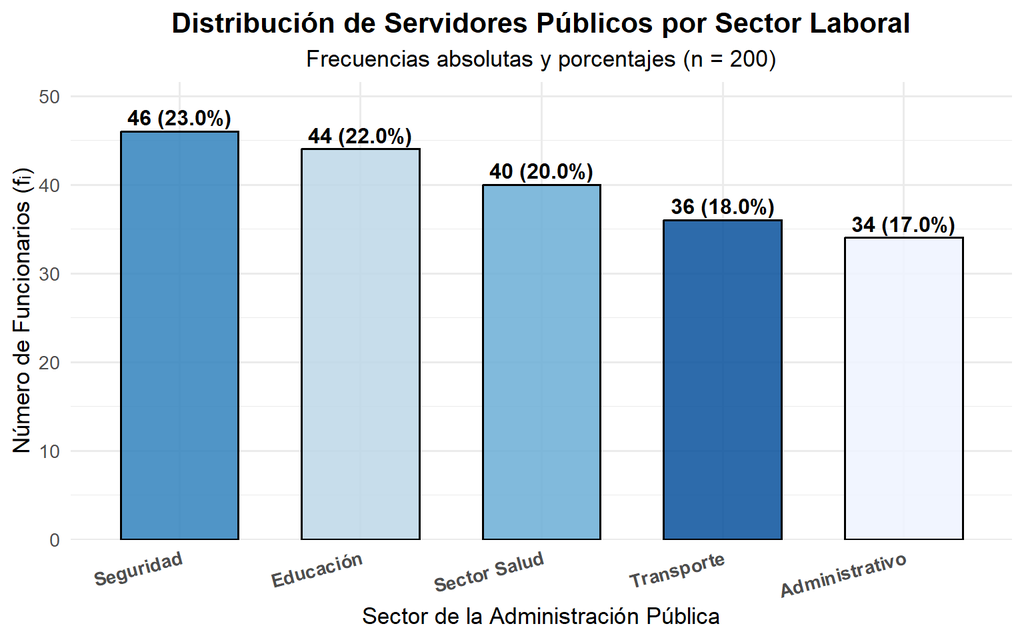

```r
df_graf_sector <- as.data.frame(table(datos$Sector_Laboral))
colnames(df_graf_sector) <- c("Sector", "Conteo")
df_graf_sector <- df_graf_sector %>%
  mutate(
    Porcentaje = Conteo / sum(Conteo) * 100,
    Etiqueta = paste0(Conteo, " (", sprintf("%.1f%%", Porcentaje), ")")
  )

ggplot(df_graf_sector, aes(x = reorder(Sector, -Conteo), y = Conteo, fill = Sector)) +
  geom_col(width = 0.65, color = "black", alpha = 0.85, show.legend = FALSE) +
  geom_text(aes(label = Etiqueta), vjust = -0.4, fontface = "bold", size = 4.2) +
  scale_fill_brewer(palette = "Blues") +
  scale_y_continuous(expand = expansion(mult = c(0, 0.12))) +
  labs(
    title = "Distribución de Servidores Públicos por Sector Laboral",
    subtitle = "Frecuencias absolutas y porcentajes (n = 200)",
    x = "Sector de la Administración Pública",
    y = "Número de Funcionarios (fᵢ)"
  ) +
  theme_minimal(base_size = 13) +
  theme(
    plot.title = element_text(face = "bold", hjust = 0.5),
    plot.subtitle = element_text(hjust = 0.5),
    axis.text.x = element_text(face = "bold", angle = 15, hjust = 1)
  )
```

### 4.1.3 Interpretación Estadística

1. **Moda de la distribución:** El sector con mayor concentración de personal es **Seguridad**, agrupando a $46$ funcionarios que representan el $23.00\%$ del total de encuestados.
2. **Sectores misionales prioritarios:** El sector **Educación** constituye el segundo grupo con $44$ empleados ($22.00\%$), seguido por el **Sector Salud** con $40$ empleados ($20.00\%$). Conjuntamente, estas tres dependencias fundamentales del Estado concentran al $65.00\%$ ($130$ funcionarios) de la fuerza de trabajo analizada.
3. **Sectores con menor proporción:** Por su parte, el sector **Transporte** cuenta con $36$ trabajadores ($18.00\%$) y el sector **Administrativo** con $34$ trabajadores ($17.00\%$).
4. **Nota metodológica:** Al tratarse de una escala nominal, el orden de las categorías en la tabla es descriptivo. Las frecuencias acumuladas ($F_i, H_i, P_i$) dependen del orden de listado y carecen de un significado jerárquico intrínseco.

# 5 SECCIÓN 2: VARIABLES ORDINALES

Las **variables cualitativas ordinales** clasifican a los individuos en categorías que guardan una relación de orden o gradación lógica intrínseca, permitiendo la interpretación directa y coherente de las frecuencias acumuladas ($F_i$ y $P_i\%$).

## 5.1 Nivel de Ingresos (`Nivel_Ingresos`)

- **Definición conceptual:** Clasificación socioeconómica del nivel salarial percibido por el servidor público dentro de la entidad gubernamental.
- **Clasificación:** Cualitativa Ordinal.
- **Orden jerárquico:** Baja $\prec$ Media $\prec$ Alta.

### 5.1.1 Tabla de Distribución de Frecuencias

**Ver código**

```r
tb_ingresos <- generar_tabla_cat(datos$Nivel_Ingresos, "Nivel de Ingresos")

kbl(tb_ingresos, caption = "Tabla 2. Distribución de frecuencias según el Nivel de Ingresos") |>
  kable_styling(bootstrap_options = c("striped", "hover", "condensed"), full_width = FALSE) |>
  row_spec(nrow(tb_ingresos), bold = TRUE, background = "#2b5c8f", color = "white")
```

Tabla 2. Distribución de frecuencias según el Nivel de Ingresos

| Nivel de Ingresos (xᵢ) | fᵢ | Fᵢ | hᵢ | Hᵢ | pᵢ (%) | Pᵢ (%) |
| --- | --- | --- | --- | --- | --- | --- |
| Baja | 71 | 71 | 0.3550 | 0.3550 | 35.50% | 35.50% |
| Media | 63 | 134 | 0.3150 | 0.6700 | 31.50% | 67.00% |
| Alta | 66 | 200 | 0.3300 | 1.0000 | 33.00% | 100.00% |
| Total | 200 | - | 1.0000 | - | 100.00% | - |

### 5.1.2 Gráfico Estadístico

**Ver código**

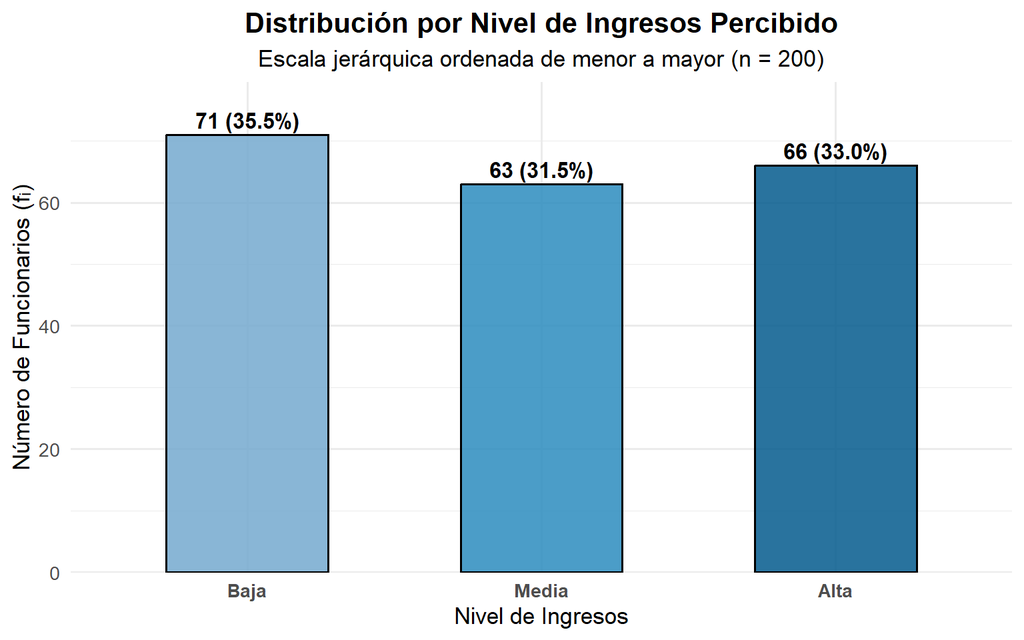

```r
df_graf_ing <- as.data.frame(table(datos$Nivel_Ingresos))
colnames(df_graf_ing) <- c("Nivel", "Conteo")
df_graf_ing <- df_graf_ing %>%
  mutate(
    Porcentaje = Conteo / sum(Conteo) * 100,
    Etiqueta = paste0(Conteo, " (", sprintf("%.1f%%", Porcentaje), ")")
  )

ggplot(df_graf_ing, aes(x = Nivel, y = Conteo, fill = Nivel)) +
  geom_col(width = 0.55, color = "black", alpha = 0.85, show.legend = FALSE) +
  geom_text(aes(label = Etiqueta), vjust = -0.4, fontface = "bold", size = 4.3) +
  scale_fill_manual(values = c("#74a9cf", "#2b8cbe", "#045a8d")) +
  scale_y_continuous(expand = expansion(mult = c(0, 0.12))) +
  labs(
    title = "Distribución por Nivel de Ingresos Percibido",
    subtitle = "Escala jerárquica ordenada de menor a mayor (n = 200)",
    x = "Nivel de Ingresos",
    y = "Número de Funcionarios (fᵢ)"
  ) +
  theme_minimal(base_size = 13) +
  theme(
    plot.title = element_text(face = "bold", hjust = 0.5),
    plot.subtitle = element_text(hjust = 0.5),
    axis.text.x = element_text(face = "bold")
  )
```

### 5.1.3 Interpretación Estadística

1. **Estrato modal:** El nivel de ingresos **Bajo** concentra la mayor cantidad de trabajadores con $71$ personas, equivalente al $35.50\%$ de la muestra.
2. **Análisis acumulado:** Un total de $134$ funcionarios ($F_2 = 134$) perciben un nivel de ingresos catalogado entre Bajo y Medio, lo que representa el $67.00\%$ acumulado ($P_2 = 67.00\%$) de la nómina estudiada.
3. **Estrato superior:** Únicamente $66$ funcionarios ($33.00\%$) se ubican en el nivel de ingresos **Alto**. Se observa un reparto relativamente equilibrado entre los tres tercios de la escala, con una leve dominancia del segmento salarial inferior.

## 5.2 Satisfacción con el Servicio (`Satisfaccion_Servicio`)

- **Definición conceptual:** Evaluación subjetiva del servidor público frente a la calidad, pertinencia y oportunidad de los servicios prestados o recibidos en su entorno laboral.
- **Clasificación:** Cualitativa Ordinal (Escala tipo Likert de 5 niveles).
- **Orden jerárquico:** Muy Insatisfecho $\prec$ Insatisfecho $\prec$ Neutral $\prec$ Satisfecho $\prec$ Muy Satisfecho.

### 5.2.1 Tabla de Distribución de Frecuencias

**Ver código**

```r
tb_sat_serv <- generar_tabla_cat(datos$Satisfaccion_Servicio, "Satisfacción del Servicio")

kbl(tb_sat_serv, caption = "Tabla 3. Distribución de frecuencias del nivel de Satisfacción con el Servicio") |>
  kable_styling(bootstrap_options = c("striped", "hover", "condensed"), full_width = FALSE) |>
  row_spec(nrow(tb_sat_serv), bold = TRUE, background = "#2b5c8f", color = "white")
```

Tabla 3. Distribución de frecuencias del nivel de Satisfacción con el Servicio

| Satisfacción del Servicio (xᵢ) | fᵢ | Fᵢ | hᵢ | Hᵢ | pᵢ (%) | Pᵢ (%) |
| --- | --- | --- | --- | --- | --- | --- |
| Muy Insatisfecho | 43 | 43 | 0.2150 | 0.2150 | 21.50% | 21.50% |
| Insatisfecho | 40 | 83 | 0.2000 | 0.4150 | 20.00% | 41.50% |
| Neutral | 37 | 120 | 0.1850 | 0.6000 | 18.50% | 60.00% |
| Satisfecho | 38 | 158 | 0.1900 | 0.7900 | 19.00% | 79.00% |
| Muy Satisfecho | 42 | 200 | 0.2100 | 1.0000 | 21.00% | 100.00% |
| Total | 200 | - | 1.0000 | - | 100.00% | - |

### 5.2.2 Gráfico Estadístico

**Ver código**

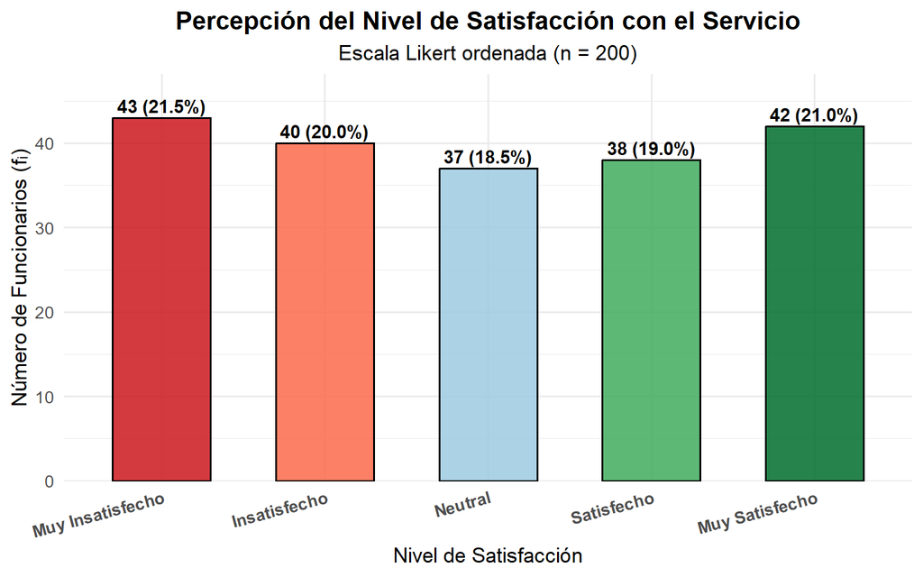

```r
df_graf_serv <- as.data.frame(table(datos$Satisfaccion_Servicio))
colnames(df_graf_serv) <- c("Nivel", "Conteo")
df_graf_serv <- df_graf_serv %>%
  mutate(
    Porcentaje = Conteo / sum(Conteo) * 100,
    Etiqueta = paste0(Conteo, " (", sprintf("%.1f%%", Porcentaje), ")")
  )

ggplot(df_graf_serv, aes(x = Nivel, y = Conteo, fill = Nivel)) +
  geom_col(width = 0.6, color = "black", alpha = 0.85, show.legend = FALSE) +
  geom_text(aes(label = Etiqueta), vjust = -0.4, fontface = "bold", size = 4) +
  scale_fill_manual(values = c("#cb181d", "#fb6a4a", "#9ecae1", "#41ab5d", "#006d2c")) +
  scale_y_continuous(expand = expansion(mult = c(0, 0.12))) +
  labs(
    title = "Percepción del Nivel de Satisfacción con el Servicio",
    subtitle = "Escala Likert ordenada (n = 200)",
    x = "Nivel de Satisfacción",
    y = "Número de Funcionarios (fᵢ)"
  ) +
  theme_minimal(base_size = 13) +
  theme(
    plot.title = element_text(face = "bold", hjust = 0.5),
    plot.subtitle = element_text(hjust = 0.5),
    axis.text.x = element_text(face = "bold", angle = 15, hjust = 1)
  )
```

### 5.2.3 Interpretación Estadística

1. **Percepción de insatisfacción:** El $41.50\%$ de los funcionarios ($F_2 = 83$) se declara insatisfecho con el servicio, desglosado en un $21.50\%$ ($43$ personas) en “Muy Insatisfecho” y un $20.00\%$ ($40$ personas) en “Insatisfecho”. La categoría “Muy Insatisfecho” resulta ser la moda general de la variable ($f_1 = 43$).
2. **Postura neutral:** El $18.50\%$ ($37$ encuestados) manifiesta una posición intermedia o “Neutral”, acumulando hasta allí al $60.00\%$ de la población ($F_3 = 120$).
3. **Percepción favorable:** En el polo positivo, el $40.00\%$ ($80$ funcionarios) expresa una evaluación positiva, repartida entre “Satisfecho” ($19.00\%$, $38$ personas) y “Muy Satisfecho” ($21.00\%$, $42$ personas).
4. **Bipolaridad observada:** La distribución presenta un patrón bimodal y dividido casi a partes iguales entre funcionarios insatisfechos ($41.50\%$) y satisfechos ($40.00\%$), lo cual indica que las intervenciones institucionales deben focalizarse prioritariamente en los focos de fricción que generan descontento extremo.

## 5.3 Frecuencia de Participación (`Frecuencia_Participacion`)

- **Definición conceptual:** Nivel de involucramiento y concurrencia activa de los empleados en actividades, comités y programas de la administración pública.
- **Clasificación:** Cualitativa Ordinal.
- **Orden jerárquico:** Nunca $\prec$ Rara vez $\prec$ A veces $\prec$ Frecuentemente $\prec$ Siempre.

### 5.3.1 Tabla de Distribución de Frecuencias

**Ver código**

```r
tb_frec_part <- generar_tabla_cat(datos$Frecuencia_Participacion, "Frecuencia de Participación")

kbl(tb_frec_part, caption = "Tabla 4. Distribución de frecuencias de la Frecuencia de Participación") |>
  kable_styling(bootstrap_options = c("striped", "hover", "condensed"), full_width = FALSE) |>
  row_spec(nrow(tb_frec_part), bold = TRUE, background = "#2b5c8f", color = "white")
```

Tabla 4. Distribución de frecuencias de la Frecuencia de Participación

| Frecuencia de Participación (xᵢ) | fᵢ | Fᵢ | hᵢ | Hᵢ | pᵢ (%) | Pᵢ (%) |
| --- | --- | --- | --- | --- | --- | --- |
| Nunca | 32 | 32 | 0.1600 | 0.1600 | 16.00% | 16.00% |
| Rara vez | 37 | 69 | 0.1850 | 0.3450 | 18.50% | 34.50% |
| A veces | 46 | 115 | 0.2300 | 0.5750 | 23.00% | 57.50% |
| Frecuentemente | 37 | 152 | 0.1850 | 0.7600 | 18.50% | 76.00% |
| Siempre | 48 | 200 | 0.2400 | 1.0000 | 24.00% | 100.00% |
| Total | 200 | - | 1.0000 | - | 100.00% | - |

### 5.3.2 Gráfico Estadístico

**Ver código**

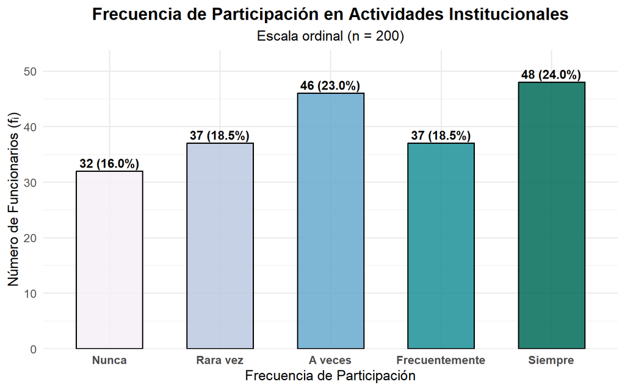

```r
df_graf_frec <- as.data.frame(table(datos$Frecuencia_Participacion))
colnames(df_graf_frec) <- c("Nivel", "Conteo")
df_graf_frec <- df_graf_frec %>%
  mutate(
    Porcentaje = Conteo / sum(Conteo) * 100,
    Etiqueta = paste0(Conteo, " (", sprintf("%.1f%%", Porcentaje), ")")
  )

ggplot(df_graf_frec, aes(x = Nivel, y = Conteo, fill = Nivel)) +
  geom_col(width = 0.6, color = "black", alpha = 0.85, show.legend = FALSE) +
  geom_text(aes(label = Etiqueta), vjust = -0.4, fontface = "bold", size = 4) +
  scale_fill_brewer(palette = "PuBuGn") +
  scale_y_continuous(expand = expansion(mult = c(0, 0.12))) +
  labs(
    title = "Frecuencia de Participación en Actividades Institucionales",
    subtitle = "Escala ordinal (n = 200)",
    x = "Frecuencia de Participación",
    y = "Número de Funcionarios (fᵢ)"
  ) +
  theme_minimal(base_size = 13) +
  theme(
    plot.title = element_text(face = "bold", hjust = 0.5),
    plot.subtitle = element_text(hjust = 0.5),
    axis.text.x = element_text(face = "bold")
  )
```

### 5.3.3 Interpretación Estadística

1. **Moda de participación:** La categoría con mayor número de servidores públicos es **Siempre**, registrando $48$ funcionarios ($24.00\%$).
2. **Participación baja a moderada:** Más de la mitad de los trabajadores ($F_3 = 115$, es decir, el $57.50\%$) participa únicamente “A veces” o con menor periodicidad ($16.00\%$ “Nunca”, $18.50\%$ “Rara vez” y $23.00\%$ “A veces”).
3. **Participación asidua:** El $42.50\%$ restante ($85$ funcionarios) interactúa frecuentemente en las iniciativas institucionales ($18.50\%$ “Frecuentemente” y $24.00\%$ “Siempre”), lo que evidencia un núcleo comprometido de servidores receptivos al desarrollo institucional.

# 6 SECCIÓN 3: VARIABLES DISCRETAS

Las **variables cuantitativas discretas** provienen de procesos de conteo y toman valores numéricos aislados pertenecientes al conjunto de los números enteros ($\mathbb{Z}^+$ o $\mathbb{N}_0$). Al tratarse de variables numéricas, se complementan con estadísticos de tendencia central, dispersión y forma calculados mediante `psych::describe()`.

## 6.1 Años de Experiencia (`Anos_Experiencia`)

- **Definición conceptual:** Cantidad entera de años de servicio prestados en el sector público.
- **Clasificación:** Cuantitativa Discreta.
- **Rango observado:** Valores enteros comprendidos entre $0$ y $20$ años.

### 6.1.1 Tabla de Distribución de Frecuencias

**Ver código**

```r
tb_exp <- generar_tabla_cat(factor(datos$Anos_Experiencia, levels = 0:20), "Años de Experiencia")

kbl(tb_exp, caption = "Tabla 5. Distribución de frecuencias para Años de Experiencia (0 a 20 años)") |>
  kable_styling(bootstrap_options = c("striped", "hover", "condensed"), full_width = FALSE) |>
  row_spec(nrow(tb_exp), bold = TRUE, background = "#2b5c8f", color = "white")
```

Tabla 5. Distribución de frecuencias para Años de Experiencia (0 a 20 años)

| Años de Experiencia (xᵢ) | fᵢ | Fᵢ | hᵢ | Hᵢ | pᵢ (%) | Pᵢ (%) |
| --- | --- | --- | --- | --- | --- | --- |
| 0 | 9 | 9 | 0.0450 | 0.0450 | 4.50% | 4.50% |
| 1 | 21 | 30 | 0.1050 | 0.1500 | 10.50% | 15.00% |
| 2 | 5 | 35 | 0.0250 | 0.1750 | 2.50% | 17.50% |
| 3 | 7 | 42 | 0.0350 | 0.2100 | 3.50% | 21.00% |
| 4 | 3 | 45 | 0.0150 | 0.2250 | 1.50% | 22.50% |
| 5 | 10 | 55 | 0.0500 | 0.2750 | 5.00% | 27.50% |
| 6 | 11 | 66 | 0.0550 | 0.3300 | 5.50% | 33.00% |
| 7 | 6 | 72 | 0.0300 | 0.3600 | 3.00% | 36.00% |
| 8 | 17 | 89 | 0.0850 | 0.4450 | 8.50% | 44.50% |
| 9 | 9 | 98 | 0.0450 | 0.4900 | 4.50% | 49.00% |
| 10 | 9 | 107 | 0.0450 | 0.5350 | 4.50% | 53.50% |
| 11 | 11 | 118 | 0.0550 | 0.5900 | 5.50% | 59.00% |
| 12 | 11 | 129 | 0.0550 | 0.6450 | 5.50% | 64.50% |
| 13 | 7 | 136 | 0.0350 | 0.6800 | 3.50% | 68.00% |
| 14 | 10 | 146 | 0.0500 | 0.7300 | 5.00% | 73.00% |
| 15 | 7 | 153 | 0.0350 | 0.7650 | 3.50% | 76.50% |
| 16 | 10 | 163 | 0.0500 | 0.8150 | 5.00% | 81.50% |
| 17 | 7 | 170 | 0.0350 | 0.8500 | 3.50% | 85.00% |
| 18 | 10 | 180 | 0.0500 | 0.9000 | 5.00% | 90.00% |
| 19 | 10 | 190 | 0.0500 | 0.9500 | 5.00% | 95.00% |
| 20 | 10 | 200 | 0.0500 | 1.0000 | 5.00% | 100.00% |
| Total | 200 | - | 1.0000 | - | 100.00% | - |

### 6.1.2 Estadísticos Descriptivos (`psych::describe`)

**Ver código**

```r
desc_exp <- formatear_describe(datos$Anos_Experiencia, "Años de Experiencia", digits = 2)

kbl(desc_exp, caption = "Estadísticos descriptivos para Años de Experiencia (psych::describe)") |>
  kable_styling(bootstrap_options = c("striped", "hover", "condensed"), full_width = FALSE) |>
  row_spec(0, bold = TRUE, background = "#34495e", color = "white")
```

Estadísticos descriptivos para Años de Experiencia (psych::describe)

| Variable | n | Media | Desv. Est. | Mediana | Mínimo | Máximo | Rango | Asimetría | Curtosis | Error Est. |
| --- | --- | --- | --- | --- | --- | --- | --- | --- | --- | --- |
| Años de Experiencia | 200 | 9.84 | 6.15 | 10.00 | 0.00 | 20.00 | 20.00 | 0.01 | -1.18 | 0.43 |

### 6.1.3 Gráfico Estadístico (Bastones y Dispersión Discreta)

**Ver código**

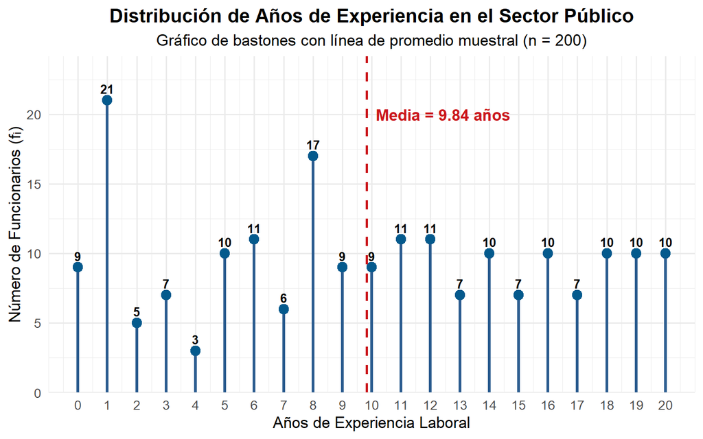

```r
df_graf_exp <- as.data.frame(table(factor(datos$Anos_Experiencia, levels = 0:20)))
colnames(df_graf_exp) <- c("Anos", "Conteo")
df_graf_exp$Anos_num <- as.numeric(as.character(df_graf_exp$Anos))

ggplot(df_graf_exp, aes(x = Anos_num, y = Conteo)) +
  geom_segment(aes(x = Anos_num, xend = Anos_num, y = 0, yend = Conteo), color = "#2b5c8f", linewidth = 1.2) +
  geom_point(color = "#045a8d", size = 3.5) +
  geom_text(aes(label = Conteo), vjust = -0.7, fontface = "bold", size = 3.5) +
  geom_vline(xintercept = mean(datos$Anos_Experiencia), color = "#cb181d", linetype = "dashed", linewidth = 1) +
  annotate("text", x = mean(datos$Anos_Experiencia) + 0.3, y = max(df_graf_exp$Conteo) - 1,
           label = paste0("Media = ", sprintf("%.2f", mean(datos$Anos_Experiencia)), " años"),
           color = "#cb181d", fontface = "bold", hjust = 0) +
  scale_x_continuous(breaks = 0:20) +
  scale_y_continuous(expand = expansion(mult = c(0, 0.15))) +
  labs(
    title = "Distribución de Años de Experiencia en el Sector Público",
    subtitle = "Gráfico de bastones con línea de promedio muestral (n = 200)",
    x = "Años de Experiencia Laboral",
    y = "Número de Funcionarios (fᵢ)"
  ) +
  theme_minimal(base_size = 13) +
  theme(
    plot.title = element_text(face = "bold", hjust = 0.5),
    plot.subtitle = element_text(hjust = 0.5)
  )
```

## 6.2 Número de Hijos (`Numero_Hijos`)

- **Definición conceptual:** Número total de hijos a cargo del empleado público encuestado.
- **Clasificación:** Cuantitativa Discreta.
- **Rango observado:** Valores enteros de $1$ a $5$ hijos.

### 6.2.1 Tabla de Distribución de Frecuencias

**Ver código**

```r
tb_hijos <- generar_tabla_cat(factor(datos$Numero_Hijos, levels = 1:5), "Número de Hijos")

kbl(tb_hijos, caption = "Tabla 6. Distribución de frecuencias para Número de Hijos (1 a 5)") |>
  kable_styling(bootstrap_options = c("striped", "hover", "condensed"), full_width = FALSE) |>
  row_spec(nrow(tb_hijos), bold = TRUE, background = "#2b5c8f", color = "white")
```

Tabla 6. Distribución de frecuencias para Número de Hijos (1 a 5)

| Número de Hijos (xᵢ) | fᵢ | Fᵢ | hᵢ | Hᵢ | pᵢ (%) | Pᵢ (%) |
| --- | --- | --- | --- | --- | --- | --- |
| 1 | 39 | 39 | 0.1950 | 0.1950 | 19.50% | 19.50% |
| 2 | 38 | 77 | 0.1900 | 0.3850 | 19.00% | 38.50% |
| 3 | 38 | 115 | 0.1900 | 0.5750 | 19.00% | 57.50% |
| 4 | 48 | 163 | 0.2400 | 0.8150 | 24.00% | 81.50% |
| 5 | 37 | 200 | 0.1850 | 1.0000 | 18.50% | 100.00% |
| Total | 200 | - | 1.0000 | - | 100.00% | - |

### 6.2.2 Estadísticos Descriptivos (`psych::describe`)

**Ver código**

```r
desc_hijos <- formatear_describe(datos$Numero_Hijos, "Número de Hijos", digits = 2)

kbl(desc_hijos, caption = "Estadísticos descriptivos para Número de Hijos (psych::describe)") |>
  kable_styling(bootstrap_options = c("striped", "hover", "condensed"), full_width = FALSE) |>
  row_spec(0, bold = TRUE, background = "#34495e", color = "white")
```

Estadísticos descriptivos para Número de Hijos (psych::describe)

| Variable | n | Media | Desv. Est. | Mediana | Mínimo | Máximo | Rango | Asimetría | Curtosis | Error Est. |
| --- | --- | --- | --- | --- | --- | --- | --- | --- | --- | --- |
| Número de Hijos | 200 | 3.03 | 1.40 | 3.00 | 1.00 | 5.00 | 4.00 | -0.07 | -1.30 | 0.10 |

### 6.2.3 Gráfico Estadístico (Barras y Conteo)

**Ver código**

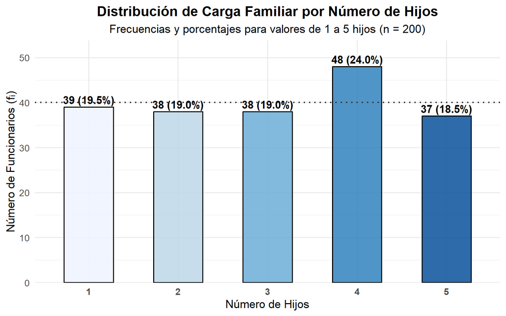

```r
df_graf_hijos <- as.data.frame(table(factor(datos$Numero_Hijos, levels = 1:5)))
colnames(df_graf_hijos) <- c("Hijos", "Conteo")
df_graf_hijos <- df_graf_hijos %>%
  mutate(
    Porcentaje = Conteo / sum(Conteo) * 100,
    Etiqueta = paste0(Conteo, " (", sprintf("%.1f%%", Porcentaje), ")")
  )

ggplot(df_graf_hijos, aes(x = Hijos, y = Conteo, fill = Hijos)) +
  geom_col(width = 0.55, color = "black", alpha = 0.85, show.legend = FALSE) +
  geom_text(aes(label = Etiqueta), vjust = -0.4, fontface = "bold", size = 4.3) +
  geom_hline(yintercept = mean(df_graf_hijos$Conteo), linetype = "dotted", color = "gray20", linewidth = 0.8) +
  scale_fill_brewer(palette = "Blues") +
  scale_y_continuous(expand = expansion(mult = c(0, 0.12))) +
  labs(
    title = "Distribución de Carga Familiar por Número de Hijos",
    subtitle = "Frecuencias y porcentajes para valores de 1 a 5 hijos (n = 200)",
    x = "Número de Hijos",
    y = "Número de Funcionarios (fᵢ)"
  ) +
  theme_minimal(base_size = 13) +
  theme(
    plot.title = element_text(face = "bold", hjust = 0.5),
    plot.subtitle = element_text(hjust = 0.5),
    axis.text.x = element_text(face = "bold")
  )
```

# 7 SECCIÓN 4: VARIABLES CONTINUAS (AGRUPADAS POR INTERVALOS)

Las **variables cuantitativas continuas** pueden asumir cualquier valor dentro de un intervalo real continuo ($\mathbb{R}$). Para su análisis tabular descriptivo se organizan en clases o intervalos disjuntos empleando la **Regla de Sturges**, la cual calcula el número óptimo de clases $k$ en función del tamaño muestral $n$:

$$k = \lceil 1 + 3.322 \log_{10}(200) \rceil = \lceil 8.644 \rceil = 9 \text{ intervalos}$$

Para cada intervalo $[L_i, L_s)$ se determina su **marca de clase** ($x_i = \frac{L_i + L_s}{2}$) y su amplitud ($A = \frac{\text{Rango}}{k}$).

## 7.1 Salario Mensual (`Salario`)

- **Definición conceptual:** Remuneración bruta mensual en miles de pesos colombianos (COP). Por ejemplo, un valor de $1085$ equivale a $\$1.085.000$ COP, y un valor de $4963$ a $\$4.963.000$ COP.
- **Clasificación:** Cuantitativa Continua agrupada en $9$ intervalos.

### 7.1.1 Tabla de Distribución de Frecuencias

**Ver código**

```r
tb_salario <- generar_tabla_continua(datos$Salario, k = 9, digits = 2, nombre_columna = "Salario (miles COP)")

kbl(tb_salario, caption = "Tabla 7. Distribución de frecuencias del Salario Mensual (9 intervalos de Sturges)") |>
  kable_styling(bootstrap_options = c("striped", "hover", "condensed"), full_width = FALSE) |>
  row_spec(nrow(tb_salario), bold = TRUE, background = "#2b5c8f", color = "white")
```

Tabla 7. Distribución de frecuencias del Salario Mensual (9 intervalos de Sturges)

| Salario (miles COP) [Lᵢ, Lₛ) | Marca (xᵢ) | fᵢ | Fᵢ | hᵢ | Hᵢ | pᵢ (%) | Pᵢ (%) |
| --- | --- | --- | --- | --- | --- | --- | --- |
| [1085.00, 1515.89) | 1300.44 | 22 | 22 | 0.1100 | 0.1100 | 11.00% | 11.00% |
| [1515.89, 1946.78) | 1731.33 | 13 | 35 | 0.0650 | 0.1750 | 6.50% | 17.50% |
| [1946.78, 2377.67) | 2162.22 | 19 | 54 | 0.0950 | 0.2700 | 9.50% | 27.00% |
| [2377.67, 2808.56) | 2593.11 | 20 | 74 | 0.1000 | 0.3700 | 10.00% | 37.00% |
| [2808.56, 3239.44) | 3024.00 | 17 | 91 | 0.0850 | 0.4550 | 8.50% | 45.50% |
| [3239.44, 3670.33) | 3454.89 | 25 | 116 | 0.1250 | 0.5800 | 12.50% | 58.00% |
| [3670.33, 4101.22) | 3885.78 | 23 | 139 | 0.1150 | 0.6950 | 11.50% | 69.50% |
| [4101.22, 4532.11) | 4316.67 | 28 | 167 | 0.1400 | 0.8350 | 14.00% | 83.50% |
| [4532.11, 4963.00] | 4747.56 | 33 | 200 | 0.1650 | 1.0000 | 16.50% | 100.00% |
| Total | - | 200 | - | 1.0000 | - | 100.00% | - |

### 7.1.2 Estadísticos Descriptivos (`psych::describe`)

**Ver código**

```r
desc_salario <- formatear_describe(datos$Salario, "Salario (miles COP)", digits = 2)

kbl(desc_salario, caption = "Estadísticos descriptivos del Salario Mensual en miles de COP (psych::describe)") |>
  kable_styling(bootstrap_options = c("striped", "hover", "condensed"), full_width = FALSE) |>
  row_spec(0, bold = TRUE, background = "#34495e", color = "white")
```

Estadísticos descriptivos del Salario Mensual en miles de COP (psych::describe)

| Variable | n | Media | Desv. Est. | Mediana | Mínimo | Máximo | Rango | Asimetría | Curtosis | Error Est. |
| --- | --- | --- | --- | --- | --- | --- | --- | --- | --- | --- |
| Salario (miles COP) | 200 | 3235.87 | 1168.60 | 3412.00 | 1085.00 | 4963.00 | 3878.00 | -0.28 | -1.20 | 82.63 |

### 7.1.3 Gráfico Estadístico (Histograma, Polígono de Frecuencias y Media)

**Ver código**

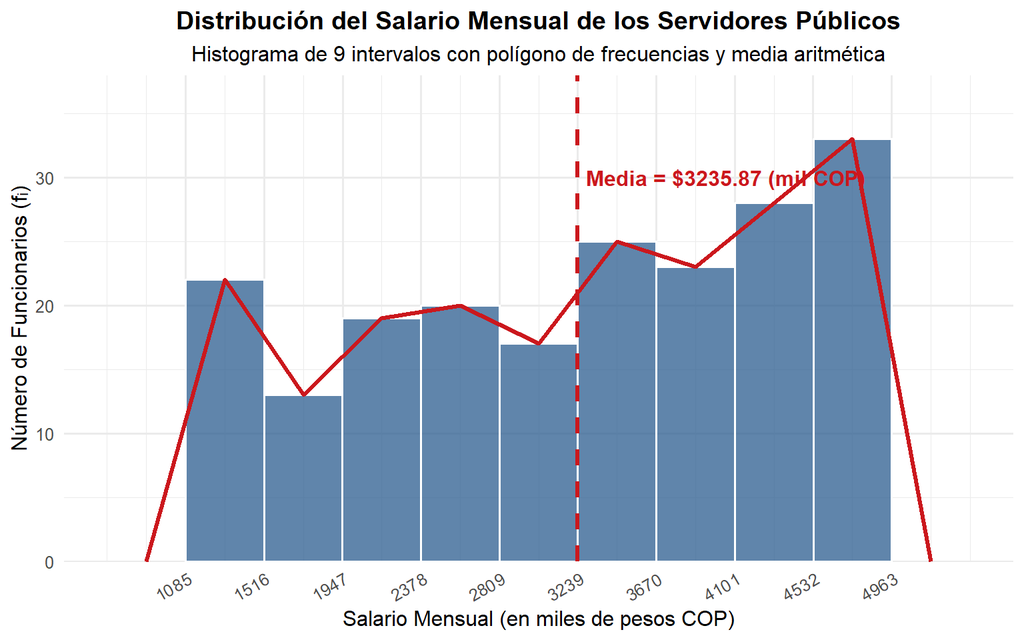

```r
breaks_sal <- seq(min(datos$Salario), max(datos$Salario), length.out = 10)

ggplot(datos, aes(x = Salario)) +
  geom_histogram(breaks = breaks_sal, fill = "#2b5c8f", color = "white", alpha = 0.75) +
  geom_freqpoly(breaks = breaks_sal, color = "#cb181d", linewidth = 1.1) +
  geom_vline(xintercept = mean(datos$Salario), color = "#cb181d", linetype = "dashed", linewidth = 1.1) +
  annotate("text", x = mean(datos$Salario) + 50, y = 30,
           label = paste0("Media = $", sprintf("%.2f", mean(datos$Salario)), " (mil COP)"),
           color = "#cb181d", fontface = "bold", hjust = 0) +
  scale_x_continuous(breaks = round(breaks_sal, 0)) +
  scale_y_continuous(expand = expansion(mult = c(0, 0.15))) +
  labs(
    title = "Distribución del Salario Mensual de los Servidores Públicos",
    subtitle = "Histograma de 9 intervalos con polígono de frecuencias y media aritmética",
    x = "Salario Mensual (en miles de pesos COP)",
    y = "Número de Funcionarios (fᵢ)"
  ) +
  theme_minimal(base_size = 12) +
  theme(
    plot.title = element_text(face = "bold", hjust = 0.5),
    plot.subtitle = element_text(hjust = 0.5),
    axis.text.x = element_text(angle = 30, hjust = 1)
  )
```

### 7.1.4 Interpretación Estadística

1. **Promedio y mediana salarial:** El salario promedio de los funcionarios es de $\bar{x} = 3235.87$ miles de pesos, lo que equivale a **$3.235.870 COP**, con un error estándar de $SE = \$82.630$ COP. La mediana se ubica en **$3.412.000 COP** ($Me = 3412.00$), indicando que el $50\%$ de los empleados devenga un sueldo menor o igual a este monto.
2. **Dispersión salarial:** La desviación estándar es de $s = 1168.60$ miles de pesos ($1.168.600 COP) sobre un rango de $3.878.000 COP ($Mín = \$1.085.000, Máx = \$4.963.000$), arrojando un coeficiente de variación de $CV = (1168.60 / 3235.87) \times 100 = 36.11\%$, lo que denota una variabilidad moderada en la escala salarial del sector.
3. **Intervalo modal:** La clase con mayor concentración de trabajadores corresponde al intervalo superior $[4532.11, 4963.00]$ miles de pesos, con $33$ empleados ($16.50\%$), seguido por el intervalo $[4101.22, 4532.11)$ con $28$ empleados ($14.00\%$). Conjuntamente, el $30.50\%$ de la muestra devenga salarios en los dos escalafones más altos.
4. **Forma de la distribución:** El coeficiente de asimetría de $-0.28$ señala un sesgo negativo ligero hacia los ingresos medios y altos, ratificado por una curtosis de $-1.20$.

## 7.2 Satisfacción Laboral (`Satisfaccion_Laboral`)

- **Definición conceptual:** Nivel de complacencia y bienestar con el clima organizacional evaluado en un índice numérico continuo de $0.5$ a $2.5$ puntos.
- **Clasificación:** Cuantitativa Continua agrupada en $9$ intervalos.

### 7.2.1 Tabla de Distribución de Frecuencias

**Ver código**

```r
tb_sat_lab <- generar_tabla_continua(datos$Satisfaccion_Laboral, k = 9, digits = 2, nombre_columna = "Satisfacción Laboral")

kbl(tb_sat_lab, caption = "Tabla 8. Distribución de frecuencias de Satisfacción Laboral (9 intervalos)") |>
  kable_styling(bootstrap_options = c("striped", "hover", "condensed"), full_width = FALSE) |>
  row_spec(nrow(tb_sat_lab), bold = TRUE, background = "#2b5c8f", color = "white")
```

Tabla 8. Distribución de frecuencias de Satisfacción Laboral (9 intervalos)

| Satisfacción Laboral [Lᵢ, Lₛ) | Marca (xᵢ) | fᵢ | Fᵢ | hᵢ | Hᵢ | pᵢ (%) | Pᵢ (%) |
| --- | --- | --- | --- | --- | --- | --- | --- |
| [0.54, 0.76) | 0.65 | 14 | 14 | 0.0700 | 0.0700 | 7.00% | 7.00% |
| [0.76, 0.98) | 0.87 | 22 | 36 | 0.1100 | 0.1800 | 11.00% | 18.00% |
| [0.98, 1.19) | 1.08 | 15 | 51 | 0.0750 | 0.2550 | 7.50% | 25.50% |
| [1.19, 1.41) | 1.30 | 20 | 71 | 0.1000 | 0.3550 | 10.00% | 35.50% |
| [1.41, 1.63) | 1.52 | 31 | 102 | 0.1550 | 0.5100 | 15.50% | 51.00% |
| [1.63, 1.85) | 1.74 | 25 | 127 | 0.1250 | 0.6350 | 12.50% | 63.50% |
| [1.85, 2.06) | 1.96 | 21 | 148 | 0.1050 | 0.7400 | 10.50% | 74.00% |
| [2.06, 2.28) | 2.17 | 30 | 178 | 0.1500 | 0.8900 | 15.00% | 89.00% |
| [2.28, 2.50] | 2.39 | 22 | 200 | 0.1100 | 1.0000 | 11.00% | 100.00% |
| Total | - | 200 | - | 1.0000 | - | 100.00% | - |

### 7.2.2 Estadísticos Descriptivos (`psych::describe`)

**Ver código**

```r
desc_sat_lab <- formatear_describe(datos$Satisfaccion_Laboral, "Satisfacción Laboral", digits = 2)

kbl(desc_sat_lab, caption = "Estadísticos descriptivos de Satisfacción Laboral (psych::describe)") |>
  kable_styling(bootstrap_options = c("striped", "hover", "condensed"), full_width = FALSE) |>
  row_spec(0, bold = TRUE, background = "#34495e", color = "white")
```

Estadísticos descriptivos de Satisfacción Laboral (psych::describe)

| Variable | n | Media | Desv. Est. | Mediana | Mínimo | Máximo | Rango | Asimetría | Curtosis | Error Est. |
| --- | --- | --- | --- | --- | --- | --- | --- | --- | --- | --- |
| Satisfacción Laboral | 200 | 1.60 | 0.54 | 1.61 | 0.54 | 2.50 | 1.96 | -0.15 | -1.07 | 0.04 |

### 7.2.3 Gráfico Estadístico (Histograma y Polígono)

**Ver código**

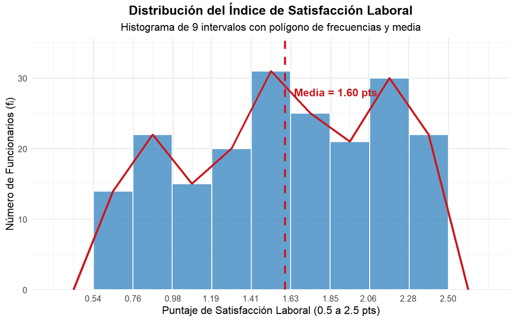

```r
breaks_sat_lab <- seq(min(datos$Satisfaccion_Laboral), max(datos$Satisfaccion_Laboral), length.out = 10)

ggplot(datos, aes(x = Satisfaccion_Laboral)) +
  geom_histogram(breaks = breaks_sat_lab, fill = "#3182bd", color = "white", alpha = 0.75) +
  geom_freqpoly(breaks = breaks_sat_lab, color = "#cb181d", linewidth = 1.1) +
  geom_vline(xintercept = mean(datos$Satisfaccion_Laboral), color = "#cb181d", linetype = "dashed", linewidth = 1.1) +
  annotate("text", x = mean(datos$Satisfaccion_Laboral) + 0.05, y = 28,
           label = paste0("Media = ", sprintf("%.2f", mean(datos$Satisfaccion_Laboral)), " pts"),
           color = "#cb181d", fontface = "bold", hjust = 0) +
  scale_x_continuous(breaks = round(breaks_sat_lab, 2)) +
  scale_y_continuous(expand = expansion(mult = c(0, 0.15))) +
  labs(
    title = "Distribución del Índice de Satisfacción Laboral",
    subtitle = "Histograma de 9 intervalos con polígono de frecuencias y media",
    x = "Puntaje de Satisfacción Laboral (0.5 a 2.5 pts)",
    y = "Número de Funcionarios (fᵢ)"
  ) +
  theme_minimal(base_size = 12) +
  theme(
    plot.title = element_text(face = "bold", hjust = 0.5),
    plot.subtitle = element_text(hjust = 0.5)
  )
```

### 7.2.4 Interpretación Estadística

1. **Nivel central:** La media de satisfacción laboral es de $\bar{x} = 1.60$ puntos (con una desviación estándar de $s = 0.54$ puntos) y una mediana de $Me = 1.61$ puntos. Los puntajes oscilan desde un mínimo de $0.54$ hasta un máximo de $2.50$ puntos.
2. **Intervalos modales:** La mayor densidad de respuestas se registra en el intervalo central $[1.41, 1.63)$ con $31$ trabajadores ($15.50\%$), seguido por el intervalo $[2.06, 2.28)$ con $30$ empleados ($15.00\%$).
3. **Distribución acumulada:** El $51.00\%$ de los funcionarios se sitúa en puntuaciones iguales o inferiores a $1.63$ puntos ($F_5 = 102$). El $49.00\%$ restante ($98$ funcionarios) puntúa en niveles óptimos superiores a $1.63$.
4. **Forma:** La asimetría es muy baja ($-0.15$) y la curtosis es de $-1.07$, demostrando que la satisfacción se halla dispersa armónicamente a lo largo de toda la escala.

## 7.3 Edad (`Edad`)

- **Definición conceptual:** Edad cronológica del servidor público en años cumplidos.
- **Clasificación:** Cuantitativa Continua agrupada en $9$ intervalos.
- **Rango observado:** De $20$ a $60$ años.

### 7.3.1 Tabla de Distribución de Frecuencias

**Ver código**

```r
tb_edad <- generar_tabla_continua(datos$Edad, k = 9, digits = 2, nombre_columna = "Edad (años)")

kbl(tb_edad, caption = "Tabla 9. Distribución de frecuencias de la Edad de los funcionarios (9 intervalos)") |>
  kable_styling(bootstrap_options = c("striped", "hover", "condensed"), full_width = FALSE) |>
  row_spec(nrow(tb_edad), bold = TRUE, background = "#2b5c8f", color = "white")
```

Tabla 9. Distribución de frecuencias de la Edad de los funcionarios (9 intervalos)

| Edad (años) [Lᵢ, Lₛ) | Marca (xᵢ) | fᵢ | Fᵢ | hᵢ | Hᵢ | pᵢ (%) | Pᵢ (%) |
| --- | --- | --- | --- | --- | --- | --- | --- |
| [20.00, 24.44) | 22.22 | 26 | 26 | 0.1300 | 0.1300 | 13.00% | 13.00% |
| [24.44, 28.89) | 26.67 | 21 | 47 | 0.1050 | 0.2350 | 10.50% | 23.50% |
| [28.89, 33.33) | 31.11 | 23 | 70 | 0.1150 | 0.3500 | 11.50% | 35.00% |
| [33.33, 37.78) | 35.56 | 19 | 89 | 0.0950 | 0.4450 | 9.50% | 44.50% |
| [37.78, 42.22) | 40.00 | 23 | 112 | 0.1150 | 0.5600 | 11.50% | 56.00% |
| [42.22, 46.67) | 44.44 | 22 | 134 | 0.1100 | 0.6700 | 11.00% | 67.00% |
| [46.67, 51.11) | 48.89 | 19 | 153 | 0.0950 | 0.7650 | 9.50% | 76.50% |
| [51.11, 55.56) | 53.33 | 24 | 177 | 0.1200 | 0.8850 | 12.00% | 88.50% |
| [55.56, 60.00] | 57.78 | 23 | 200 | 0.1150 | 1.0000 | 11.50% | 100.00% |
| Total | - | 200 | - | 1.0000 | - | 100.00% | - |

### 7.3.2 Estadísticos Descriptivos (`psych::describe`)

**Ver código**

```r
desc_edad <- formatear_describe(datos$Edad, "Edad (años)", digits = 2)

kbl(desc_edad, caption = "Estadísticos descriptivos de la Edad de los funcionarios (psych::describe)") |>
  kable_styling(bootstrap_options = c("striped", "hover", "condensed"), full_width = FALSE) |>
  row_spec(0, bold = TRUE, background = "#34495e", color = "white")
```

Estadísticos descriptivos de la Edad de los funcionarios (psych::describe)

| Variable | n | Media | Desv. Est. | Mediana | Mínimo | Máximo | Rango | Asimetría | Curtosis | Error Est. |
| --- | --- | --- | --- | --- | --- | --- | --- | --- | --- | --- |
| Edad (años) | 200 | 39.92 | 11.92 | 39.50 | 20.00 | 60.00 | 40.00 | 0.00 | -1.30 | 0.84 |

### 7.3.3 Gráfico Estadístico (Histograma y Polígono)

**Ver código**

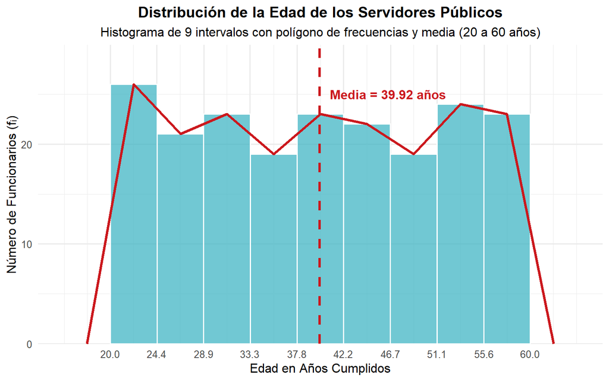

```r
breaks_edad <- seq(min(datos$Edad), max(datos$Edad), length.out = 10)

ggplot(datos, aes(x = Edad)) +
  geom_histogram(breaks = breaks_edad, fill = "#41b6c4", color = "white", alpha = 0.75) +
  geom_freqpoly(breaks = breaks_edad, color = "#cb181d", linewidth = 1.1) +
  geom_vline(xintercept = mean(datos$Edad), color = "#cb181d", linetype = "dashed", linewidth = 1.1) +
  annotate("text", x = mean(datos$Edad) + 1, y = 25,
           label = paste0("Media = ", sprintf("%.2f", mean(datos$Edad)), " años"),
           color = "#cb181d", fontface = "bold", hjust = 0) +
  scale_x_continuous(breaks = round(breaks_edad, 1)) +
  scale_y_continuous(expand = expansion(mult = c(0, 0.15))) +
  labs(
    title = "Distribución de la Edad de los Servidores Públicos",
    subtitle = "Histograma de 9 intervalos con polígono de frecuencias y media (20 a 60 años)",
    x = "Edad en Años Cumplidos",
    y = "Número de Funcionarios (fᵢ)"
  ) +
  theme_minimal(base_size = 12) +
  theme(
    plot.title = element_text(face = "bold", hjust = 0.5),
    plot.subtitle = element_text(hjust = 0.5)
  )
```

### 7.3.4 Interpretación Estadística

1. **Parámetros centrales:** La edad promedio del personal es de $\bar{x} = 39.92$ años con una desviación estándar de $s = 11.92$ años. La mediana es de $Me = 39.50$ años, prácticamente idéntica a la media.
2. **Equilibrio etario:** El coeficiente de asimetría es exactamente de $0.00$, lo cual evidencia una **simetría perfecta**. La edad mínima es de $20$ años y la máxima de $60$ años ($Rango = 40$ años).
3. **Distribución por rangos:** Cada uno de los $9$ intervalos congrega entre $19$ y $26$ funcionarios (entre el $9.50\%$ y el $13.00\%$), reflejando una estructura demográfica rectangular y muy equilibrada:
   - Jóvenes ($20$ a $24.4$ años): $26$ funcionarios ($13.00\%$).
   - Adultos jóvenes ($24.4$ a $37.8$ años): $63$ funcionarios ($31.50\%$).
   - Adultos medios ($37.8$ a $51.1$ años): $64$ funcionarios ($32.00\%$).
   - Adultos mayores ($51.1$ a $60$ años): $47$ funcionarios ($23.50\%$).
4. Esta composición asegura experiencia consolidada sin comprometer el recambio generacional de la entidad pública.

## 7.4 Participación en Programas (`Participacion_Programas`)

- **Definición conceptual:** Proporción de cumplimiento y asistencia del servidor a los programas institucionales de formación, capacitación y bienestar (rango de $0.1$ a $1.0$, equivalente a $10\%$ a $100\%$).
- **Clasificación:** Cuantitativa Continua agrupada en $9$ intervalos.

### 7.4.1 Tabla de Distribución de Frecuencias

**Ver código**

```r
tb_prog <- generar_tabla_continua(datos$Participacion_Programas, k = 9, digits = 3, nombre_columna = "Participación Programas")

kbl(tb_prog, caption = "Tabla 10. Distribución de frecuencias de Participación en Programas (9 intervalos)") |>
  kable_styling(bootstrap_options = c("striped", "hover", "condensed"), full_width = FALSE) |>
  row_spec(nrow(tb_prog), bold = TRUE, background = "#2b5c8f", color = "white")
```

Tabla 10. Distribución de frecuencias de Participación en Programas (9 intervalos)

| Participación Programas [Lᵢ, Lₛ) | Marca (xᵢ) | fᵢ | Fᵢ | hᵢ | Hᵢ | pᵢ (%) | Pᵢ (%) |
| --- | --- | --- | --- | --- | --- | --- | --- |
| [0.100, 0.198) | 0.149 | 22 | 22 | 0.1100 | 0.1100 | 11.00% | 11.00% |
| [0.198, 0.296) | 0.247 | 19 | 41 | 0.0950 | 0.2050 | 9.50% | 20.50% |
| [0.296, 0.394) | 0.345 | 24 | 65 | 0.1200 | 0.3250 | 12.00% | 32.50% |
| [0.394, 0.492) | 0.443 | 34 | 99 | 0.1700 | 0.4950 | 17.00% | 49.50% |
| [0.492, 0.590) | 0.541 | 16 | 115 | 0.0800 | 0.5750 | 8.00% | 57.50% |
| [0.590, 0.688) | 0.639 | 18 | 133 | 0.0900 | 0.6650 | 9.00% | 66.50% |
| [0.688, 0.786) | 0.737 | 21 | 154 | 0.1050 | 0.7700 | 10.50% | 77.00% |
| [0.786, 0.884) | 0.835 | 21 | 175 | 0.1050 | 0.8750 | 10.50% | 87.50% |
| [0.884, 0.982] | 0.933 | 25 | 200 | 0.1250 | 1.0000 | 12.50% | 100.00% |
| Total | - | 200 | - | 1.0000 | - | 100.00% | - |

### 7.4.2 Estadísticos Descriptivos (`psych::describe`)

**Ver código**

```r
desc_prog <- formatear_describe(datos$Participacion_Programas, "Participación Programas", digits = 2)

kbl(desc_prog, caption = "Estadísticos descriptivos de Participación en Programas (psych::describe)") |>
  kable_styling(bootstrap_options = c("striped", "hover", "condensed"), full_width = FALSE) |>
  row_spec(0, bold = TRUE, background = "#34495e", color = "white")
```

Estadísticos descriptivos de Participación en Programas (psych::describe)

| Variable | n | Media | Desv. Est. | Mediana | Mínimo | Máximo | Rango | Asimetría | Curtosis | Error Est. |
| --- | --- | --- | --- | --- | --- | --- | --- | --- | --- | --- |
| Participación Programas | 200 | 0.54 | 0.26 | 0.50 | 0.10 | 0.98 | 0.88 | 0.07 | -1.22 | 0.02 |

### 7.4.3 Gráfico Estadístico (Histograma y Polígono)

**Ver código**

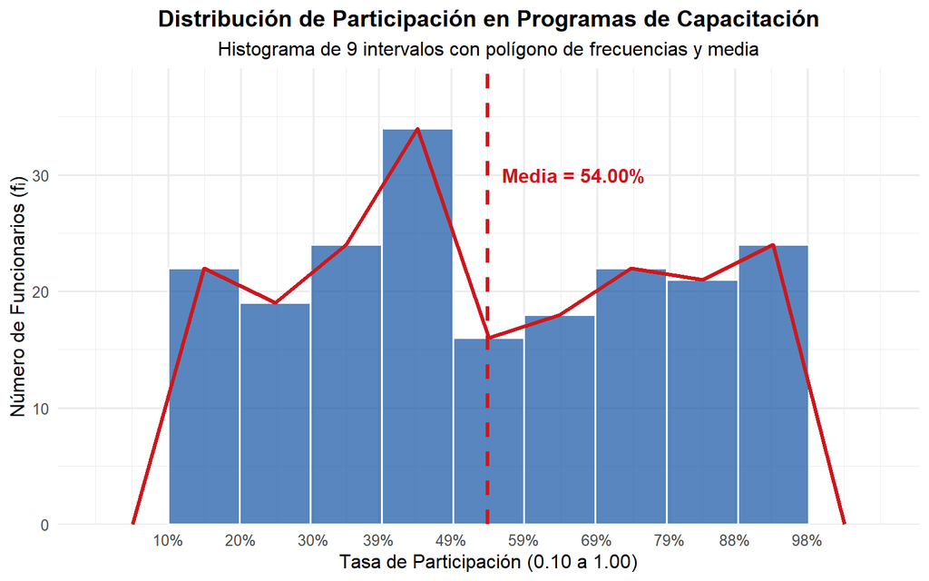

```r
breaks_prog <- seq(min(datos$Participacion_Programas), max(datos$Participacion_Programas), length.out = 10)

ggplot(datos, aes(x = Participacion_Programas)) +
  geom_histogram(breaks = breaks_prog, fill = "#225ea8", color = "white", alpha = 0.75) +
  geom_freqpoly(breaks = breaks_prog, color = "#cb181d", linewidth = 1.1) +
  geom_vline(xintercept = mean(datos$Participacion_Programas), color = "#cb181d", linetype = "dashed", linewidth = 1.1) +
  annotate("text", x = mean(datos$Participacion_Programas) + 0.02, y = 30,
           label = paste0("Media = ", sprintf("%.2f", mean(datos$Participacion_Programas) * 100), "%"),
           color = "#cb181d", fontface = "bold", hjust = 0) +
  scale_x_continuous(breaks = round(breaks_prog, 2), labels = scales::percent_format(accuracy = 1)) +
  scale_y_continuous(expand = expansion(mult = c(0, 0.15))) +
  labs(
    title = "Distribución de Participación en Programas de Capacitación",
    subtitle = "Histograma de 9 intervalos con polígono de frecuencias y media",
    x = "Tasa de Participación (0.10 a 1.00)",
    y = "Número de Funcionarios (fᵢ)"
  ) +
  theme_minimal(base_size = 12) +
  theme(
    plot.title = element_text(face = "bold", hjust = 0.5),
    plot.subtitle = element_text(hjust = 0.5)
  )
```

### 7.4.4 Interpretación Estadística

1. **Tasa de participación promedio:** La tasa media de participación se sitúa en $\bar{x} = 0.54$ ($54.00\%$), con una desviación típica de $s = 0.26$ ($26.00\%$). La mediana es de $Me = 0.50$ ($50.00\%$).
2. **Intervalo modal:** La clase con mayor cantidad de participantes es $[0.394, 0.492)$ con $34$ empleados ($17.00\%$), seguida por el grupo de alta adherencia formativa $[0.884, 0.982]$ con $25$ trabajadores ($12.50\%$).
3. **Distribución acumulada:** El $49.50\%$ de los funcionarios asiste al $49.2\%$ o menos de las jornadas de formación ($F_4 = 99$), en tanto que el $50.50\%$ restante ($101$ funcionarios) supera dicho umbral, evidenciando un compromiso notable con la capacitación laboral continua.
4. **Forma:** El sesgo es muy leve hacia la derecha ($Asimetría = 0.07$), ratificando un comportamiento equilibrado y disperso entre los niveles básico, intermedio y avanzado de capacitación.

# 8 Conclusiones y Síntesis General

El análisis exhaustivo de las $10$ variables de la base de datos `sector.xlsx` ($n = 200$) permite extraer conclusiones sustantivas sobre la dinámica del talento humano en la administración pública: